# Homework 2

**Due Date:** 2022-10-16 at 8:30 AM PT

**Name:** Ben Senator

For this assignment, you will practice downloadings, cleaning, and analyzing data from the [National Risk Index (NRI)](https://hazards.fema.gov/nri/) and the [CDC Social Vulnerability Index (SVI)](https://www.atsdr.cdc.gov/placeandhealth/svi/index.html).

## Preparation

1. Create a ‘data’ folder in the root directory of your repository.
2. Inside the ‘data’ folder, create a ‘raw’ folder.
3. Add and commit a ‘.gitignore’ file to the root directory of this repository that excludes all contents of the ‘data’ folder.
4. Download the county-level NRI and SVI data for the entire United States. Place the data in the ‘data/raw’ folder.
5. In the repository README, provide a brief (1-2 sentence) description of each file in the ‘data’ folder and a link to the original source of the data.

## Task 1 - NRI Data Cleaning

**1. Import the NRI data. Ensure that the [FIPS code](https://en.wikipedia.org/wiki/Federal_Information_Processing_Standard_state_code) variable (‘STCOFIPS’) is correctly identified as a string / character variable. Otherwise, the leading zeros will be removed.**

```python
import pandas as pd
dfNRI = pd.read_csv('Data/Raw/NRI_Table_Counties.csv', dtype={"STCOFIPS": str})
print(dfNRI)
```

```
      OID_  NRI_ID           STATE STATEABBRV  STATEFIPS      COUNTY  \
0        1  C01001         Alabama         AL          1     Autauga
1        2  C01003         Alabama         AL          1     Baldwin
2        3  C01005         Alabama         AL          1     Barbour
3        4  C01007         Alabama         AL          1        Bibb
4        5  C01009         Alabama         AL          1      Blount
...    ...     ...             ...        ...        ...         ...
3226  3227  C72151     Puerto Rico         PR         72     Yabucoa
3227  3228  C72153     Puerto Rico         PR         72       Yauco
3228  3229  C78010  Virgin Islands         VI         78   St. Croix
3229  3230  C78020  Virgin Islands         VI         78    St. John
3230  3231  C78030  Virgin Islands         VI         78  St. Thomas

     COUNTYTYPE  COUNTYFIPS STCOFIPS  POPULATION  ...  WNTW_EALS  \
0        County           1    01001       58764  ...  15.784587
```

[output cut: 38 more lines]

**2. Subset the NRI data to include only the 5-digit state/county FIPS code and all colums ending with ‘_AFREQ’ and ‘_RISKR’. Each of these columns represents a different hazard type.**

```python
dfNRI = dfNRI.filter(regex='STCOFIPS|_AFREQ$|_RISKR$')
print(dfNRI)
```

```
     STCOFIPS  AVLN_AFREQ      AVLN_RISKR  CFLD_AFREQ         CFLD_RISKR  \
0       01001         NaN  Not Applicable         NaN     Not Applicable
1       01003         NaN  Not Applicable    3.684142     Relatively Low
2       01005         NaN  Not Applicable         NaN     Not Applicable
3       01007         NaN  Not Applicable         NaN     Not Applicable
4       01009         NaN  Not Applicable         NaN     Not Applicable
...       ...         ...             ...         ...                ...
3226    72151         NaN  Not Applicable    0.212000  Insufficient Data
3227    72153         NaN  Not Applicable    0.010000  Insufficient Data
3228    78010         NaN  Not Applicable    0.252000  Insufficient Data
3229    78020         NaN  Not Applicable    0.210000  Insufficient Data
3230    78030         NaN  Not Applicable    0.210000  Insufficient Data

      CWAV_AFREQ         CWAV_RISKR  DRGT_AFREQ           DRGT_RISKR  \
0            0.0          No Rating   25.969774       Relatively Low
```

[output cut: 51 more lines]

**3. Create a table / dataframe that, for each hazard type, shows the number of missing values in the ‘_AFREQ’ and ‘_RISKR’ columns.**

```python
# First reduce down to the AFREQ and RISKR cols.
dfNRISubset = dfNRI.filter(regex='_AFREQ$|_RISKR$')
# Looks good - we can calculate the number of missing rows in each col.
dfNRIMissing = dfNRISubset.isnull().sum()
# Series, not a DF: convert.
dfNRIMissing = dfNRIMissing.reset_index()
dfNRIMissing.columns = ['Variable', 'Value']
# Split the 'Variable' column into 'Type' and 'Measure'
dfNRIMissing[['Type', 'Measure']] = dfNRIMissing['Variable'].str.split('_', expand=True)
# Good - we are ready to convert to wide.
dfNRIMissingWide = dfNRIMissing.pivot(index='Type', columns='Measure', values = 'Value').reset_index()
# And rename for intuitive colnames.
dfNRIMissingWide = dfNRIMissingWide.rename(columns={'Type': 'Hazard'})
print(dfNRIMissingWide)
```

```
Measure Hazard  AFREQ  RISKR
0         AVLN   3023      0
1         CFLD   2646      0
2         CWAV      0      0
3         DRGT      7      0
4         ERQK      0      0
5         HAIL      7      0
6         HRCN    918      0
7         HWAV      0      0
8         ISTM    229      0
9         LNDS     40      0
10        LTNG    123      0
11        RFLD      0      0
12        SWND      7      0
13        TRND      7      0
14        TSUN   3103      0
15        VLCN   3125      0
16        WFIR     88      0
17        WNTW      0      0
```

**4. Create a new column in the original data table indicating whether or not ‘AVLN_AFREQ’ is missing or observed. Show the cross-tabulation of the ‘AVLN_AFREQ’ missingness and ‘AVLN_RISKR’ columns (including missing values). What do you observe?**

```python
# Let's note that we have already done the output of this in part 3, but we will also create the requested missing indicator here.
dfNRI['AVLN_AFREQ_Missing'] = dfNRI['AVLN_AFREQ'].isnull()
tblAVLNAFREQMissingByAVLNRISKR = pd.crosstab(dfNRI['AVLN_AFREQ_Missing'], dfNRI['AVLN_RISKR'], dropna=False)
print(tblAVLNAFREQMissingByAVLNRISKR)
```

```
AVLN_RISKR          Not Applicable  Relatively High  Relatively Low  \
AVLN_AFREQ_Missing
False                            0               15              52
True                          3023                0               0

AVLN_RISKR          Relatively Moderate  Very High  Very Low
AVLN_AFREQ_Missing
False                                33          9        99
True                                  0          0         0
```

We notice that the vast majority of the missing values for AVLN_AFREQ are conditional on the AVLN_RISKR variable being ‘Not Applicable’.

**5. Assuming that a risk that is “not applicable” to a county has an annualized frequency of 0, impute the relevant missing values in the ‘_AFREQ’ columns with 0.**

```python
dfNRI[dfNRI.columns[dfNRI.columns.str.endswith('_AFREQ')]] = dfNRI.filter(regex='_AFREQ$').fillna(0)
```

## Task 2 - SVI Data Cleaning

**1. Import the SVI data. Ensure that the FIPS code is correctly identified as a string / character variable. Otherwise, the leading zeros will be removed.** **1. Subset the SVI data to include only the following columns:** `ST, STATE, ST_ABBR, STCNTY, COUNTY, FIPS, LOCATION, AREA_SQMI, E_TOTPOP, EP_POV150, EP_UNEMP, EP_HBURD, EP_NOHSDP, EP_UNINSUR, EP_AGE65, EP_AGE17, EP_DISABL, EP_SNGPNT, EP_LIMENG, EP_MINRTY, EP_MUNIT, EP_MOBILE, EP_CROWD, EP_NOVEH, EP_GROUPQ, EP_NOINT, EP_AFAM, EP_HISP, EP_ASIAN, EP_AIAN, EP_NHPI, EP_TWOMORE, EP_OTHERRACE`

```python
dfSVI = pd.read_csv('Data/Raw/SVI.csv', dtype={'FIPS': str})
```

```python
# Define cols
columnsRequired = [
    'ST', 'STATE', 'ST_ABBR', 'STCNTY', 'COUNTY', 'FIPS', 'LOCATION', 'AREA_SQMI',
    'E_TOTPOP', 'EP_POV150', 'EP_UNEMP', 'EP_HBURD', 'EP_NOHSDP', 'EP_UNINSUR',
    'EP_AGE65', 'EP_AGE17', 'EP_DISABL', 'EP_SNGPNT', 'EP_LIMENG', 'EP_MINRTY',
    'EP_MUNIT', 'EP_MOBILE', 'EP_CROWD', 'EP_NOVEH', 'EP_GROUPQ', 'EP_NOINT',
    'EP_AFAM', 'EP_HISP', 'EP_ASIAN', 'EP_AIAN', 'EP_NHPI', 'EP_TWOMORE', 'EP_OTHERRACE']
# Subset to these columns
dfSVISubset = dfSVI[columnsRequired]
```

**2. Create a table / dataframe that shows the number of missing values in each column. (Hint: if you wrote a function for Task 1, you can reuse it here.)**

```python
# As above show number of missing values in each col
dfSVISubsetMissing = dfSVISubset.isnull().sum().reset_index()
dfSVISubsetMissing.columns=['Variable', 'Value']
dfSVI
print(dfSVISubsetMissing)
```

```
        Variable  Value
0             ST      0
1          STATE      0
2        ST_ABBR      0
3         STCNTY      0
4         COUNTY      0
5           FIPS      0
6       LOCATION      0
7      AREA_SQMI      0
8       E_TOTPOP      0
9      EP_POV150      0
10      EP_UNEMP      0
11      EP_HBURD      0
12     EP_NOHSDP      0
13    EP_UNINSUR      0
```

[output cut: 19 more lines]

## Task 3 - Data Merging

**1. Identify any FIPS codes that are present in the NRI data but not in the SVI data and vice versa. Describe any discrepancies and possible causes? What to these discrepancies, if any, mean for interpreting results based on the merged dataset moving forward?**

```python
# In NRI data, the FIPS codes are identified by variable STCOFIPS.
# In SVI data, this variable is just FIPS.
# First, identify FIPS codes in NRI data but not SVI.
NRIFips = set(dfNRI['STCOFIPS'])
SVIFips = set(dfSVISubset['FIPS'])
# Now we find which are not in each set.
NRIFipsNotSVI = NRIFips - SVIFips
SVIFipsNotNRI = SVIFips - NRIFips
# Print the results.
print(NRIFipsNotSVI)
print(SVIFipsNotNRI)
print("We can see that the number of FIPS codes in the NRI data but not in the SVI data is:")
print(len(NRIFipsNotSVI))
print("And the number of FIPS codes in the SVI data but not in the NRI data is:")
print(len(SVIFipsNotNRI))
# We can investigate why these discrepancies exist.
# First, we can check if the FIPS codes are formatted differently in the two datasets.
print(dfNRI['STCOFIPS'].head())
print(dfSVISubset['FIPS'].head())
# They look to be the same. We can also check if there are any missing values in the FIPS columns.
print(dfNRI['STCOFIPS'].isnull().sum())
print(dfSVISubset['FIPS'].isnull().sum())
# There are no missing values in either dataset.
# We can see which country codes the non-overlapping FIPS codes correspond to, to check if these are non-overlapping in a way that relates to their country. Use the STATE variable for this, and only on the SVI data because we don't have the STATE variable in the NRI data.
print(dfSVISubset[dfSVISubset['FIPS'].isin(SVIFipsNotNRI)]['STATE'])
# Group by STATE to see if there are any patterns.
print(dfSVISubset[dfSVISubset['FIPS'].isin(SVIFipsNotNRI)].groupby('STATE').size())
# It's not entirely clear why we have these lack of overlaps, although we do see that Connecticut has a large number of non-overlapping FIPS codes (9). There may be some state-level problems.
```

```
{'72089', '72141', '72065', '72139', '72045', '72067', '72051', '72069', '72103', '72075', '09011', '72003', '72125', '72054', '72133', '72109', '72039', '72119', '72047', '72057', '72033', '72135', '09015', '72147', '72087', '72095', '72113', '72021', '72029', '72151', '72127', '72031', '72077', '7…
{'09190', '09170', '09160', '09150', '09180', '09130', '09120', '09110', '09140'}
We can see that the number of FIPS codes in the NRI data but not in the SVI data is:
96
And the number of FIPS codes in the SVI data but not in the NRI data is:
9
0    01001
1    01003
2    01005
3    01007
4    01009
Name: STCOFIPS, dtype: object
0    01001
1    01003
2    01005
3    01007
4    01009
Name: FIPS, dtype: object
0
0
309    Connecticut
310    Connecticut
311    Connecticut
312    Connecticut
313    Connecticut
314    Connecticut
315    Connecticut
316    Connecticut
317    Connecticut
Name: STATE, dtype: object
STATE
Connecticut    9
dtype: int64
```

**2. Merge the NRI and SVI data on the FIPS code. Use an outer join to keep all counties in the final dataset.**

```python
# We merge on the FIPS code.
dfMerged = pd.merge(dfNRI, dfSVISubset, left_on='STCOFIPS', right_on='FIPS', how='outer')
# Check the result with head.
print(dfMerged.head())
# We can check if this worked by checking the number of rows in the merged dataset against the number of rows in the original datasets.
print(dfMerged.shape)
print(dfNRI.shape)
print(dfSVISubset.shape)
# Looks good.
```

```
  STCOFIPS  AVLN_AFREQ      AVLN_RISKR  CFLD_AFREQ      CFLD_RISKR  \
0    01001         0.0  Not Applicable    0.000000  Not Applicable
1    01003         0.0  Not Applicable    3.684142  Relatively Low
2    01005         0.0  Not Applicable    0.000000  Not Applicable
3    01007         0.0  Not Applicable    0.000000  Not Applicable
4    01009         0.0  Not Applicable    0.000000  Not Applicable

   CWAV_AFREQ CWAV_RISKR  DRGT_AFREQ           DRGT_RISKR  ERQK_AFREQ  ...  \
0         0.0  No Rating   25.969774       Relatively Low    0.000431  ...
1         0.0  No Rating   12.353442  Relatively Moderate    0.000338  ...
2         0.0  No Rating   43.956953       Relatively Low    0.000227  ...
3         0.0  No Rating   28.894501             Very Low    0.000790  ...
4         0.0  No Rating   28.152598       Relatively Low    0.000817  ...

  EP_NOVEH  EP_GROUPQ EP_NOINT  EP_AFAM EP_HISP  EP_ASIAN EP_AIAN  EP_NHPI  \
0      4.0        0.9     10.9     19.6     3.2       1.1     0.1      0.0
1      2.3        1.5     10.9      8.3     4.8       0.9     0.2      0.0
2     11.7       12.0     31.8     46.9     4.8       0.5     0.3      0.0
3      7.5        6.4     20.2     20.7     2.9       0.3     0.1      0.0
4      4.8        1.0     16.9      1.2     9.7       0.2     0.1      0.2

  EP_TWOMORE  EP_OTHERRACE
0        3.3           0.2
1        3.1           0.4
2        1.8           1.2
3        1.7           0.1
4        2.8           0.1

[5 rows x 71 columns]
(3240, 71)
(3231, 38)
(3144, 33)
```

**3. Create a table / dataframe that shows the number of missing values in each column of the merged dataset.**

```python
# We show the number of missing values in each column of dfMerged.
dfMergedMissing = dfMerged.isnull().sum().reset_index()
dfMergedMissing.columns = ['Variable', 'Value']
print(dfMergedMissing)
```

```
        Variable  Value
0       STCOFIPS      9
1     AVLN_AFREQ      9
2     AVLN_RISKR      9
3     CFLD_AFREQ      9
4     CFLD_RISKR      9
..           ...    ...
66      EP_ASIAN     96
67       EP_AIAN     96
68       EP_NHPI     96
69    EP_TWOMORE     96
70  EP_OTHERRACE     96

[71 rows x 2 columns]
```

## Task 4 - Data Analysis

**1. For each numerical variable in the merged dataset, plot a histogram showing the distribution of values. (Hint: write a function to make the histogram for a single variable, then use a loop or apply function to make the histograms for all numerical variables.)**

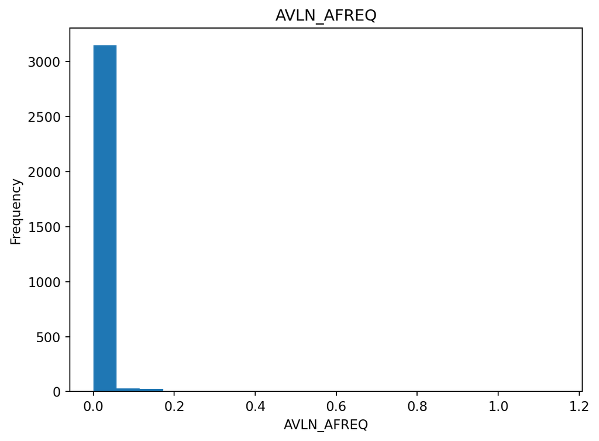

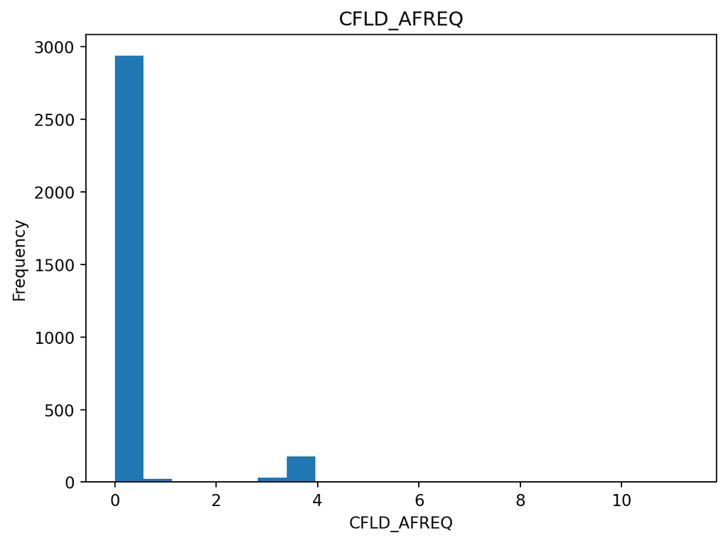

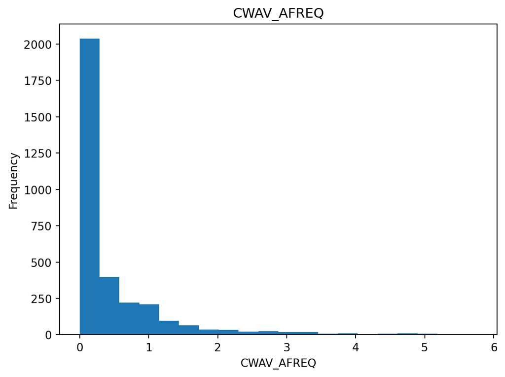

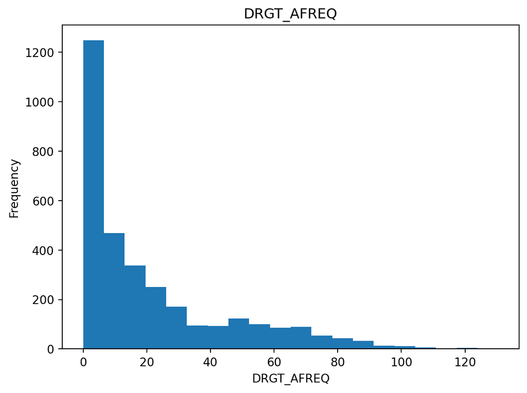

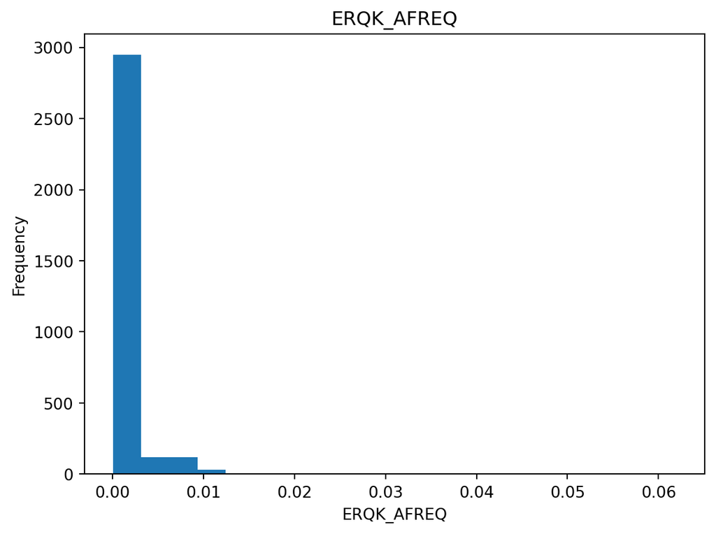

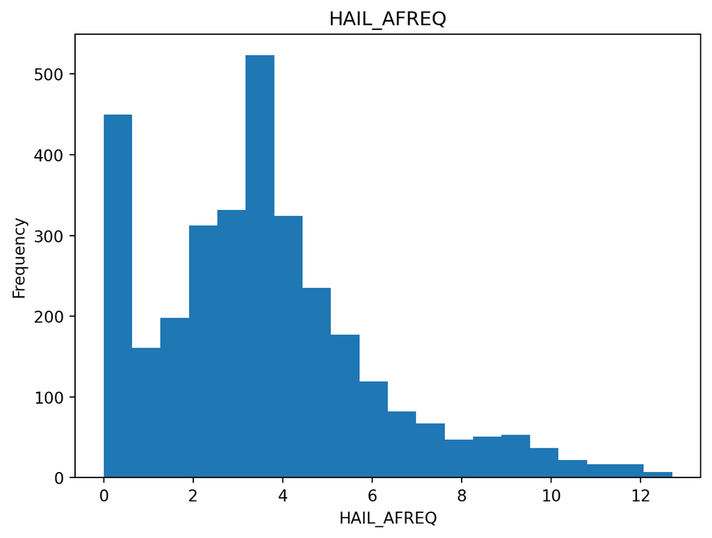

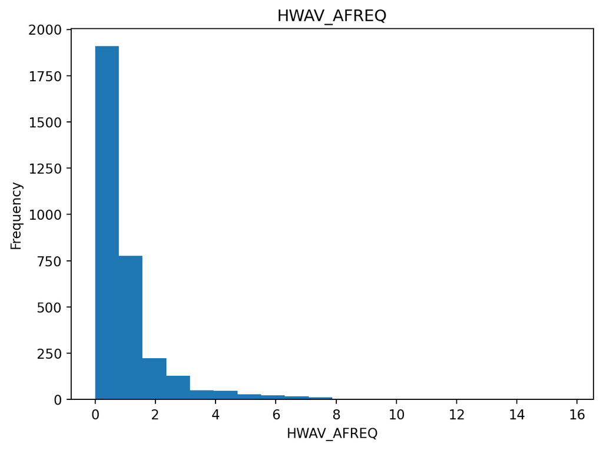

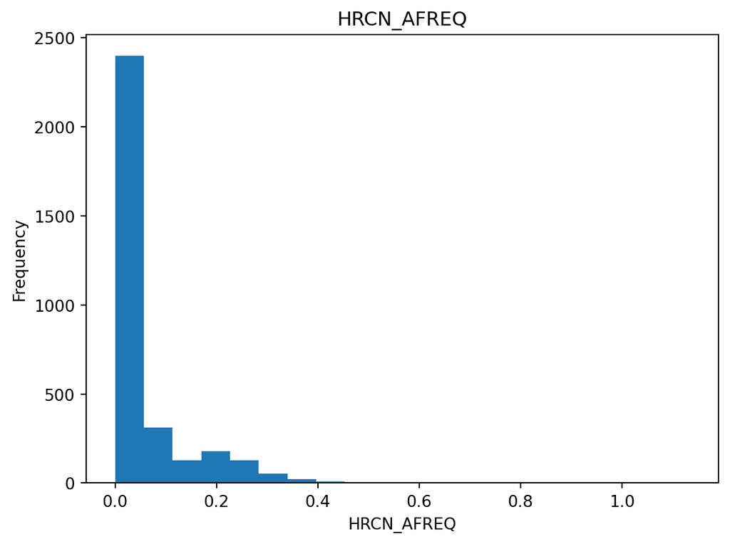

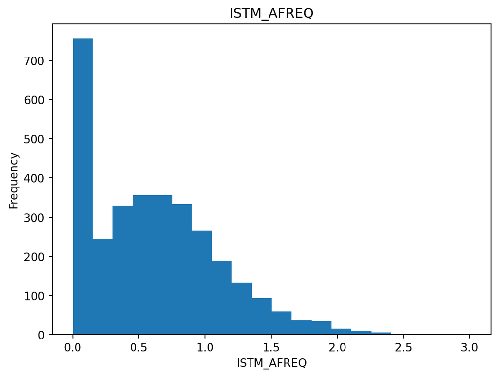

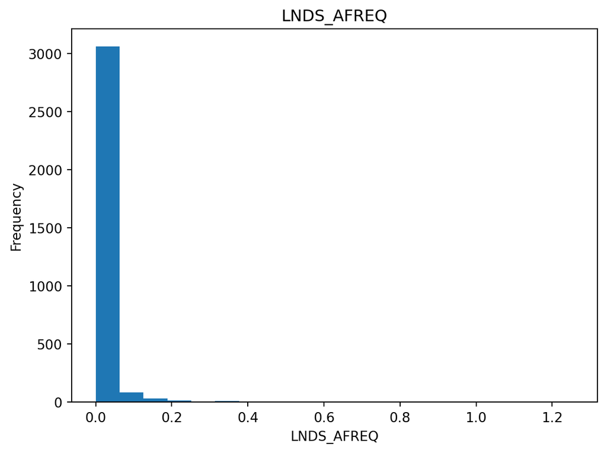

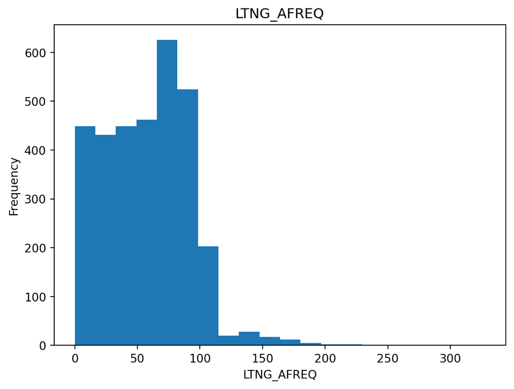

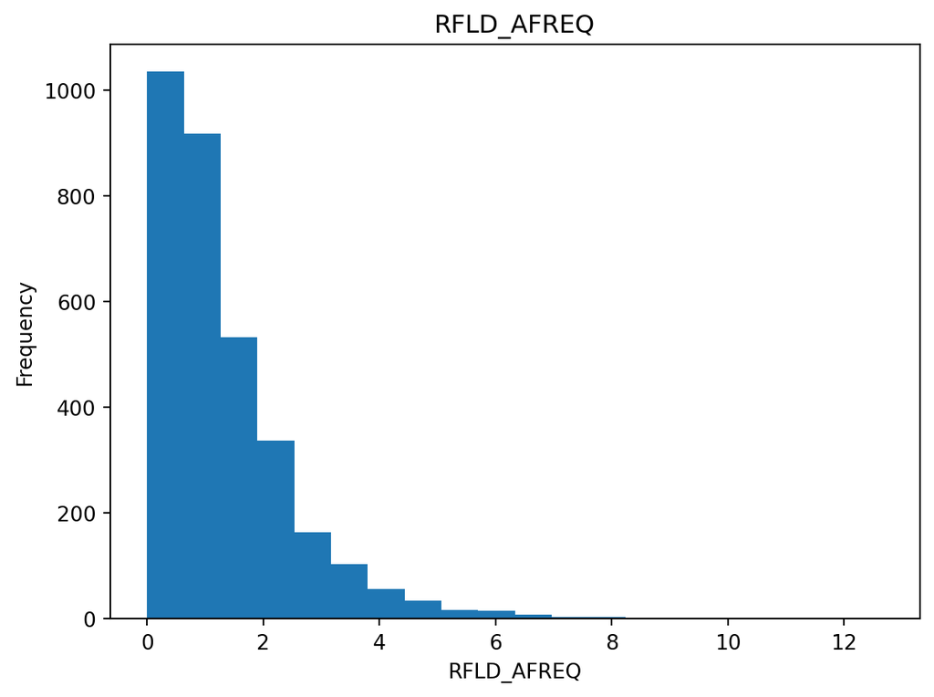

[34 more figures not shown]

```python
# We'll first identify the numerical variables.
numericalVariables = dfMerged.select_dtypes(include=['number']).columns
# Now we'll write a function to plot a histogram for a single variable.
import matplotlib.pyplot as plt
def plotHistogram(df, variable):
    plt.hist(df[variable].dropna(), bins=20)
    plt.title(variable)
    plt.xlabel(variable)
    plt.ylabel('Frequency')
    plt.show()
# Now we can use this function to plot histograms for all numerical variables.
for var in numericalVariables:
    plotHistogram(dfMerged, var)
```